# Predicting MLB game winners using the Kalman filter

Michael Moon and Aaron Situ

August 9, 2016

### Data

#### Parsing retrosheet

The data used for the study was retrieved using the package `retrosheet`. The package retrieves and parses MLB data from http://www.retrosheet.org/. The type of data that can be retrieved include play-by-play data, game logs, and schedules from as far back as 1871.

For the study, game logs for all regular season games from 2011 to 2015 seasons were downloaded. The following variables were included with the retrieved data.

- **Date**: Game date
- **HmTm**: Home team code
- **VisTm**: Visiting team code
- **HmLine**: Home team’s final line score
- **VisLine**: Visiting team’s final line score
- **DblHdr**: Doubleheader indicator (*0*: Not a doubleheader; *1*: 1st game of a doubleheader; *2*: 2nd game of a doubleheader)

Below is the code used to retrieve and parse the score differentials. Each game was separated into two lines for each of the home and away team with an indicator variable.

- **HmVis**: *+1*: Home team; *-1*: Visiting team

```r
library(retrosheet)
yrs <- c(2011:2015)
teamIds <- unique(c(sapply(yrs, getTeamIDs)))
teamIds <- teamIds[teamIds != "FLO"] # Florida Marlins changed to Miami Marlins

# Variables: Teams, Line scores, Date; DblHdr;
fields <- c("HmTm", "VisTm", "HmLine", "VisLine", "Date", "DblHdr")
dataGame <- lapply(yrs, function(x) getPartialGamelog(x, fields))
dataGame <- lapply(dataGame, as.data.frame)

parseSeason <- function(season){
  season$GID <- paste(paste(season$Date, season$HmTm, sep = "-"), season$DblHdr, sep = "")
  season$Tind <- as.numeric(factor(season$Date))
  season$Date <- as.Date(season$Date, "%Y%m%d")
  season$DblHdr <- as.factor(season$DblHdr)
  # Florida Marlins changed to Miami Marlins
  season$VisTm[season$VisTm == "FLO"] <- "MIA"
  season$VisTm <- factor(season$VisTm, teamIds)
  season$HmTm[season$HmTm == "FLO"] <- "MIA"
  season$HmTm <- factor(season$HmTm, teamIds)
  season$Host <- season$HmTm
  season$ScoreDiffHm <-
    sapply(strsplit(season$HmLine, ""),
           function(x) sum(as.numeric(x), na.rm = TRUE)) -
    sapply(strsplit(season$VisLine, ""),
           function(x) sum(as.numeric(x), na.rm = TRUE))
  tmpVis <- subset(season, select = c("GID", "Tind", "Date", "DblHdr", "VisTm",
                                      "Host", "ScoreDiffHm"))
  names(tmpVis) <- c("GID", "Tind", "Date", "DblHdr", "Team",
                     "Host", "ScoreDiff")
  tmpVis$ScoreDiff <- -tmpVis$ScoreDiff
  tmpVis$HmVis <- -1


  tmpHm <- subset(season, select = c("GID", "Tind", "Date", "DblHdr", "HmTm",
                                      "Host", "ScoreDiffHm"))
  names(tmpHm) <- c("GID", "Tind", "Date", "DblHdr", "Team",
                     "Host", "ScoreDiff")
  tmpHm$HmVis <- 1


  tmp <- rbind(tmpVis, tmpHm)
  return(tmp[order(tmp$Date, tmp$Host), ])
}

dataSeasons <- lapply(dataGame, parseSeason)
names(dataSeasons) <- c( "S2011", "S2012", "S2013", "S2014", "S2015")
```

There were total 12149games. There Below is a sample of the data after parsing.

```r
head(dataSeasons$S2011, 10)
```

```
##                GID Tind       Date DblHdr Team Host ScoreDiff HmVis
## 5    20110331-KCA0    1 2011-03-31      0  ANA  KCA         2    -1
## 2434 20110331-KCA0    1 2011-03-31      0  KCA  KCA        -2     1
## 6    20110331-NYA0    1 2011-03-31      0  DET  NYA        -3    -1
## 2435 20110331-NYA0    1 2011-03-31      0  NYA  NYA         3     1
## 1    20110331-CIN0    1 2011-03-31      0  MIL  CIN        -1    -1
## 2430 20110331-CIN0    1 2011-03-31      0  CIN  CIN         1     1
## 2    20110331-LAN0    1 2011-03-31      0  SFN  LAN        -1    -1
## 2431 20110331-LAN0    1 2011-03-31      0  LAN  LAN         1     1
## 3    20110331-SLN0    1 2011-03-31      0  SDN  SLN         2    -1
## 2432 20110331-SLN0    1 2011-03-31      0  SLN  SLN        -2     1
```

#### Parsing schedules

The following code was used to create the schedule matrices. $C_t$

```r
library(plyr)
library(reshape2)
parseMatches <- function(season){
  tmp <- ddply(season, c("Date", "Tind"),
               function(x) dcast(x, GID ~ Team, sum, value.var = "HmVis"))
  tmp[is.na(tmp)] <- 0
  tmp <- tmp[c("Date", "Tind", teamIds)] # match the column order
  return(tmp)
}

matchSeasons <- lapply(dataSeasons, parseMatches)
names(matchSeasons) <- c("S2011", "S2012", "S2013", "S2014", "S2015")
```

Below is a sample of the schedule data after parsing.

```r
head(matchSeasons$S2011, 10)
```

```
##          Date Tind ANA BAL BOS CHA CLE DET KCA MIN NYA OAK SEA TBA TEX TOR
## 1  2011-03-31    1   0   0   0   0   0   0   0   0   0   0   0   0   0   0
## 2  2011-03-31    1  -1   0   0   0   0   0   1   0   0   0   0   0   0   0
## 3  2011-03-31    1   0   0   0   0   0   0   0   0   0   0   0   0   0   0
## 4  2011-03-31    1   0   0   0   0   0  -1   0   0   1   0   0   0   0   0
## 5  2011-03-31    1   0   0   0   0   0   0   0   0   0   0   0   0   0   0
## 6  2011-03-31    1   0   0   0   0   0   0   0   0   0   0   0   0   0   0
## 7  2011-04-01    2   0   0   0   0   0   0   0   0   0   0   0   0   0   0
## 8  2011-04-01    2   0   0   0  -1   1   0   0   0   0   0   0   0   0   0
## 9  2011-04-01    2   0   0   0   0   0   0   0   0   0   0   0   0   0   0
## 10 2011-04-01    2   0   0   0   0   0   0   0   0   0   0   0   0   0   0
##    ARI ATL CHN CIN COL HOU LAN MIL NYN PHI PIT SDN SFN SLN WAS MIA
## 1    0   0   0   1   0   0   0  -1   0   0   0   0   0   0   0   0
## 2    0   0   0   0   0   0   0   0   0   0   0   0   0   0   0   0
## 3    0   0   0   0   0   0   1   0   0   0   0   0  -1   0   0   0
## 4    0   0   0   0   0   0   0   0   0   0   0   0   0   0   0   0
## 5    0   0   0   0   0   0   0   0   0   0   0  -1   0   1   0   0
## 6    0  -1   0   0   0   0   0   0   0   0   0   0   0   0   1   0
## 7    0   0   1   0   0   0   0   0   0   0  -1   0   0   0   0   0
## 8    0   0   0   0   0   0   0   0   0   0   0   0   0   0   0   0
## 9   -1   0   0   0   1   0   0   0   0   0   0   0   0   0   0   0
## 10   0   0   0   0   0   0   0   0  -1   0   0   0   0   0   0   1
```

#### Parsing score differentials

The following code was used to create the score differential vectors. $y_t$

```r
scoreSeasons <- lapply(dataSeasons, function(x) subset(x, HmVis == 1,
                  select = c("Date", "Tind", "ScoreDiff")))
names(scoreSeasons) <- c("S2011", "S2012", "S2013", "S2014", "S2015")
```

Below is a sample of the score differential data after parsing.

```r
head(scoreSeasons$S2011)
```

```
##            Date Tind ScoreDiff
## 2434 2011-03-31    1        -2
## 2435 2011-03-31    1         3
## 2430 2011-03-31    1         1
## 2431 2011-03-31    1         1
## 2432 2011-03-31    1        -2
## 2433 2011-03-31    1        -2
```

#### Parsing covariates

The following code was used to create the covariate matrices including an intercept term. $D_t$

```r
parseCovs <- function(season){
  tmp <- subset(season, HmVis == 1, select = c("Date", "Tind", "DblHdr", "Host"))
  row.names(tmp) <- NULL
  tmp <- cbind(tmp[,c(1,2)], model.matrix(~tmp$DblHdr + tmp$Host))
  return(tmp)
}
covSeasons <- lapply(dataSeasons, parseCovs)
names(covSeasons) <- c("S2011", "S2012", "S2013", "S2014", "S2015")
```

Below is a sample of the covariate matrices after parsing.

```r
head(covSeasons$S2011)[,1:8]
```

```
##         Date Tind (Intercept) tmp$DblHdr1 tmp$DblHdr2 tmp$HostBAL
## 1 2011-03-31    1           1           0           0           0
## 2 2011-03-31    1           1           0           0           0
## 3 2011-03-31    1           1           0           0           0
## 4 2011-03-31    1           1           0           0           0
## 5 2011-03-31    1           1           0           0           0
## 6 2011-03-31    1           1           0           0           0
##   tmp$HostBOS tmp$HostCHA
## 1           0           0
## 2           0           0
## 3           0           0
## 4           0           0
## 5           0           0
## 6           0           0
```

[output not shown]

For the Kalman filter functions used, the number of rows must match for different $t$’s. The following function was created to ensure all matrices and vectors had 18 - the maximum number of a game on a day - rows.

```r
getC18 <- function(t, seasoni){
  c <- getC(t, seasoni)
  return(rbind(c, matrix(0, nrow = 18 - nrow(c), ncol = ncol(c))))
}

getD18 <- function(t, seasoni, level = 2){
  d <- getD(t, seasoni, level = level)
  if(level == 0)
    return(c(d, rep(0, 18 - length(d))))
  return(rbind(d, matrix(0, nrow = 18 - nrow(d), ncol = ncol(d))))
}

getY18 <- function(t, seasoni){
  y <- getY(t, seasoni)
  return(c(y, rep(0, 18 - length(y))))
}
```

### Analysis

#### Estimating parameters

**System variances**

$\sigma_0^2, \sigma_v^2, \sigma_w^2 \in \mathbb{R}$

**Covariate coefficients**

$u = \{ u_1, \dots , u_{32} \} \in \mathbb{R}^{32}$

For the fist intercept-only model, we estimated the paramters by maximizing the log-likelihood function given below. The likelihood function can be derived from the conditional distribution of $y_t$.

**Conditional distribution** $y_t|\mathcal{Y}_{t-1}\sim N(\hat{y}_t, \hat{O}_t) \\ \text{ where }\mathcal{Y}_t:=(y'_1,\dots,y'_t); \hat{y}_t=C_{t}\hat{x}_{t|t-1}+D_{t}u; \hat{O}_t=C_{t}\hat{\Sigma}_{t|t-1}C'_{t+1}+N_{t}$ **Density** $f_{y_t|\mathcal{Y}_{t-1}}(y_t|\mathcal{Y}_{t-1}) \propto |\hat{O}_t|^{-1/2} \text{exp}\left(-\frac{1}{2}(y_t-\hat{y}_t)'\hat{O}_t^{-1}(y_t-\hat{y}_t)\right)$ **Log-likelihood** $\mathscr{l}(\sigma_0^2, \sigma_v^2, \sigma_w^2, u_1; \mathcal{Y}_T)=\sum_{t=1}^{\mathcal{Y}} \text{log }f_{y_t|\mathcal{Y}_{t-1}}(y_t|\mathcal{Y}_{t-1})$

The log-likelihood function was defined manually in R. First, the covariance matrix and the system state calculations were defined as below.

**Predictive covariance matrix** $\hat{\Sigma}_{t|t-1}=\hat{\Sigma}_{t-1|t-1}+M$

**Posterior covariance matrix** $\hat{\Sigma}_{t|t}=\hat{\Sigma}_{t|t-1}-\hat{\Sigma}_{t|t-1}C'_t(C_t\hat{\Sigma}_{t|t-1}C'_t+N_t)^{-1}C_t\hat{\Sigma}_{t|t-1}$

**System state prediction** $\hat{x}_{t|t-1}=\hat{x}_{t-1|t-1}$

**System state update** $\hat{x}_{t|t}=\hat{x}_{t-1|t-1}+\hat{\Sigma}_{t|t}C'_tN_t^{-1}(y_t-C_t\hat{x}_{t-1|t-1}-D_tu)$

```r
### Predictive covariance matrix ###
sigma_pred <- function(t, seasoni, sig0, sigW, sigV){
  sigma_post(t - 1, seasoni, sig0, sigV, sigW)
}

### Posterior covariance mtrix ###
sigma_post <- function(t, seasoni, sig0, sigV, sigW){
  if(t > 0){
    Ct <- getC(t, seasoni) # C_t
    mt <- nrow(Ct)  # m: number of games on day t
    Nt <- sigW*diag(mt) # N:
    sprev <- sigma_pred(t, seasoni, sig0, sigV, sigW)
    return(sprev -
             sprev%*%t(Ct)%*%
             solve(Ct%*%sprev%*%t(Ct) + Nt)%*%
             Ct%*%sprev)
  }
  else{
    (sig0 + sigV)*diag(30)
  }
}

### System state prediction ###
x_pred <- function(t, seasoni, x0, sig0, sigV, sigW, u, clevel = 0){
  x_post(t - 1, seasoni, x0, sig0, sigV, sigW, u, clevel)
}

### System state update ###
x_post <- function(t, seasoni, x0, sig0, sigV, sigW, u, clevel = 0){
  if(t > 0){
    Ct <- getC(t, seasoni) # C_t
    Dt <- getD(t, seasoni, clevel) # D_t
    yt <- getY(t, seasoni) # y_t, point differentials on games in t-th game day
    mt <- nrow(Ct)  # m: number of games on day t
    Nt <- sigW*diag(mt) # N:
    xprev <- x_post(t - 1, seasoni, x0, sig0, sigV, sigW, u, clevel) # X-hat_t-1 | t-1
    spost <- sigma_post(t, seasoni, sig0, sigV, sigW) # Sigma-hat_t | t
    if(clevel == 0)
      return(xprev + (1/sigW)*spost%*%t(Ct)%*%(yt - Ct%*%xprev - u*Dt))
    return(xprev + (1/sigW)*spost%*%t(Ct)%*%(yt - Ct%*%xprev - Dt%*%u))
  }
  else{
    x0
  }
}
```

Then, the negative of log-likelihood function was defined as below.

```r
### negative log-likelihood for a single game ###
loglike <- function(pars, t, seasoni, x0, u = NULL){
  sig0 <- pars[1]
  sigV <- pars[2]
  sigW <- pars[3]
  if(!is.na(pars[4])) u = pars[4]

  Ct <- getC(t, seasoni)
  Dt <- getD(t, seasoni, 0)
  Yt <- getY(t, seasoni)
  xpred <- x_pred(t, seasoni, x0, sig0, sigV, sigW, u)
  spred <- sigma_pred(t, seasoni, sig0, sigV, sigW)
  Nt <- sigW*diag(nrow(Ct))

  yhat <- Ct%*%xpred + u*Dt
  Ohat <- Ct%*%spred%*%t(Ct) + Nt

  ydiff <- Yt - yhat

  # gives negative likelihood
  loglik <- log(det(Ohat)) + t(ydiff)%*%solve(Ohat)%*%ydiff
  return(as.numeric(loglik))
}

### total negative log-likelihood for multiple games ###
nLoglike <- function(pars, seasoni, x0s, us = NULL, numdts = 20){
  x0 <- x0s[,seasoni]
  u <- us[seasoni]
  gamedays <- c(1: numdts)
  sum(sapply(gamedays, FUN = loglike, pars = pars,
              seasoni = seasoni, x0 = x0, u = u))
}
```

In order to minimize the negative log-likelihood function, `optim` function was used. The parameters were initialized with the following code.

```r
set.seed(20160806)
pars <- c(100,100,100, rnorm(1, 2))
```

$x_{0|0; \text{rank i}}:=15.5-i$

```r
library(RCurl)
franks <- list()
gitURL <- getURL("https://rawgit.com/mjmoon/timeseriesFin/master/data/rank2010.csv")
franks[[1]] <- read.csv(text = gitURL)
gitURL <- getURL("https://rawgit.com/mjmoon/timeseriesFin/master/data/rank2011.csv")
franks[[2]] <- read.csv(text = gitURL)
gitURL <- getURL("https://rawgit.com/mjmoon/timeseriesFin/master/data/rank2012.csv")
franks[[3]] <- read.csv(text = gitURL)
gitURL <- getURL("https://rawgit.com/mjmoon/timeseriesFin/master/data/rank2013.csv")
franks[[4]] <- read.csv(text = gitURL)
gitURL <- getURL("https://rawgit.com/mjmoon/timeseriesFin/master/data/rank2014.csv")
franks[[5]] <- read.csv(text = gitURL)

getx0 <- function(rankscsv){
  rankscsv <- rankscsv[-31,1:2]
  rankscsv$x0 <- 14.5:-14.5
  rankscsv$Tm <- as.character(rankscsv$Tm)
  # rankscsv$Tm[!rankscsv$Tm %in% teamIds]
  rankscsv$Tm[rankscsv$Tm == "NYY"] <- "NYA"
  rankscsv$Tm[rankscsv$Tm == "LAA"] <- "ANA"
  rankscsv$Tm[rankscsv$Tm == "LAD"] <- "LAN"
  rankscsv$Tm[rankscsv$Tm == "STL"] <- "SLN"
  rankscsv$Tm[rankscsv$Tm == "SFG"] <- "SFN"
  rankscsv$Tm[rankscsv$Tm == "FLA"] <- "MIA"
  rankscsv$Tm[rankscsv$Tm == "TBR"] <- "TBA"
  rankscsv$Tm[rankscsv$Tm == "CHC"] <- "CHN"
  rankscsv$Tm[rankscsv$Tm == "CHW"] <- "CHA"
  rankscsv$Tm[rankscsv$Tm == "SDP"] <- "SDN"
  rankscsv$Tm[rankscsv$Tm == "NYM"] <- "NYN"
  rankscsv$Tm[rankscsv$Tm == "KCR"] <- "KCA"
  rankscsv$Tm[rankscsv$Tm == "WSN"] <- "WAS"
  rankscsv$Tm <- factor(rankscsv$Tm, teamIds)
  # rankscsv$Tm[!rankscsv$Tm %in% teamIds]
  rankscsv <- rankscsv[order(rankscsv$Tm), ]
  return(rankscsv$x0)
}

x0s <- sapply(franks, getx0)
```

The optimizations were performed for each season as shown below.

```r
## intercept
parest1 <- optim(pars, nLoglike, seasoni = 1, x0s = x0s,
                 method = "L-BFGS-B",
                 lower = c(5,5,5,-0.1), upper = c(1000,1000,1000,1.5))
parest2 <- optim(pars, nLoglike, seasoni = 2, x0s = x0s,
                 method = "L-BFGS-B",
                 lower = c(5,5,5,-0.1), upper = c(1000,1000,1000,1.5))
parest4 <- optim(pars, nLoglike, seasoni = 4, x0s = x0s,
                 method = "L-BFGS-B",
                 lower = c(5,5,5,-0.1), upper = c(1000,1000,1000,1.5))
parest5 <- optim(pars, nLoglike, seasoni = 5, x0s = x0s,
                 method = "L-BFGS-B",
                 lower = c(5,5,5,-0.1), upper = c(1000,1000,1000,1.5))
parest6 <- optim(pars, nLoglike, seasoni = 6, x0s = x0s,
                 method = "L-BFGS-B",
                 lower = c(5,5,5,-0.1), upper = c(1000,1000,1000,1.5))
utoptim <- rbind(parest1$par, parest2$par, parest3$par, parest4$par, parest5$par)
colnames(utoptim) <- c("sig0", "sigV", "sigW", "u_intercept")
rownames(utoptim) <- c("S2011", "S2012", "S2013", "S2014", "S2015")
print(round(utoptim,2))
```

[output not shown]

$y=Du+\epsilon \text{ where } \epsilon \sim N(0,\sigma^2)$

```r
utlm <- t(sapply(dataSeasons, function(x)
  coef(lm(ScoreDiff ~ DblHdr + Host, data = subset(x, HmVis == 1)))))
rownames(utlm) <- c("S2011", "S2012", "S2013", "S2014", "S2015")
print(round(utlm,2))
```

```
##       (Intercept) DblHdr1 DblHdr2 HostBAL HostBOS HostCHA HostCLE HostDET
## S2011        0.22    0.69    0.13   -1.01    0.25   -0.83   -0.51    0.45
## S2012        0.48   -0.52   -0.12   -0.35   -0.52    0.10   -1.34    0.32
## S2013       -0.23   -0.24   -0.67    0.46    1.49   -0.43    0.70    1.41
## S2014        0.64    0.71   -0.11    0.03   -1.27   -1.37   -0.64   -0.70
## S2015        0.27    0.26    0.08    0.28    0.35   -0.76   -0.18   -0.74
##       HostKCA HostMIN HostNYA HostOAK HostSEA HostTBA HostTEX HostTOR
## S2011   -0.12   -1.62    1.28    0.09   -0.89    0.10    1.01   -0.60
## S2012   -0.98   -1.10    0.50    0.26   -0.52    0.31    0.43   -0.69
## S2013    0.23   -0.90    0.08    0.86   -0.58    0.74    0.93    0.05
## S2014   -1.16   -1.29   -0.93    0.50   -0.33   -0.46   -2.21    0.04
## S2015    0.51    0.35    0.12   -0.13   -0.59   -0.43    0.05    1.68
##       HostARI HostATL HostCHN HostCIN HostCOL HostHOU HostLAN HostMIL
## S2011    0.47    0.28   -0.65    0.01   -0.08   -1.32   -0.36    0.83
## S2012   -0.29    0.01   -0.85    0.04   -1.04   -1.02   -0.02    0.27
## S2013    0.31    1.78   -0.15    0.76    0.84   -1.73    0.19   -0.31
## S2014   -1.12   -0.73   -0.91   -0.41    0.04   -1.19   -0.38   -0.59
## S2015   -0.45   -1.17   -0.02   -0.97   -0.82    0.79    0.67   -0.86
##       HostNYN HostPHI HostPIT HostSDN HostSFN HostSLN HostWAS HostMIA
## S2011   -0.74    1.16   -1.13   -0.62   -0.41   -0.07   -0.16   -0.74
## S2012   -1.21   -0.75   -0.23   -0.59   -0.04    0.73    0.33   -1.20
## S2013   -0.61   -0.08    0.76    0.04   -0.38    1.55    0.93   -0.21
## S2014   -0.65   -0.93   -0.01   -0.26   -0.19   -0.35    0.37   -0.22
## S2015   -0.10   -0.96    0.49   -0.56    0.40    0.54    0.36   -0.59
```

#### The Kalman filter

The Kalman filter was fitted using the `FKF` https://cran.r-project.org/web/packages/FKF/FKF.pdf package.

```r
library(FKF)
mlbkm <- function(seasoni, covs = F){
  if(covs) {
    u <- array(c(utoptim[seasoni,-c(1:3)], utlm[seasoni,]), c(32,1))
    level <- 2
  } else {
    u <- array(utoptim[seasoni, 4], c(1, 1))
    level <- 0
  }
  gamedays <- which(!unique(scoreSeasons[[seasoni]]$Tind) %in% c(1:20))
  yt <- sapply(gamedays, getY18, seasoni)
  Ct <- sapply(gamedays, getC18, seasoni, simplify = "array")
  Dt <- sapply(gamedays, getD18, seasoni, level, simplify = "array")
  if(!covs) Dt <- array(Dt, dim = c(18, 1, ncol(Dt)))
  uDt <- apply(Dt, 3, function(x) x%*%u)

  testkf <- fkf(a0 = x0s[,seasoni],
                P0 = utoptim[seasoni, 1]*diag(30),
                dt = matrix(0, nrow = 30, ncol = 1),
                ct = uDt,
                Tt = array(diag(30), c(30,30,1)),
                Zt = Ct,
                HHt = array(utoptim[seasoni, 2]*diag(30), c(30,30,1)),
                GGt = array(utoptim[seasoni, 3]*diag(18), c(18,18,1)),
                yt)

  xtts <- testkf$att
  xts <- testkf$at
  yts <- yt - round(testkf$vt)
  ytvec <- as.vector(yt)
  winprederr <- sum((as.vector(yts > 0)[ytvec != 0]) !=
                       (ytvec[ytvec != 0] > 0))/sum(ytvec != 0)
  scoremse <- sum((as.vector(testkf$vt)[ytvec != 0])^2)/sum(ytvec != 0)
  return(list(xpost = xtts, xpred = xts, ypred = yts,
              gprederr = winprederr, smse = scoremse))
}
### Fit intercept-only model ###
kmfres.int <- lapply(c(1:5), mlbkm)
### Fit covariate model ###
kmfres.cov <- lapply(c(1:5), mlbkm, covs = T)
```

### Results

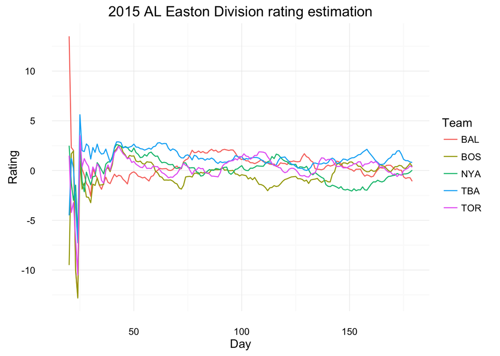

The plot above shows the estimated relative team strengths of the 5 teams in AL Easton Division during the 2015 season.